# MATH 3070 Lab Project 9

Kanishka Ragula

October 26, 2017

*Remember: I expect to see commentary either in the text, in the code with comments created using `#`, or (preferably) both! **Failing to do so may result in lost points!***

## Problem 1 (Verzani problem 3.17)

*The `state.x77` data set contains various information for each of the fifty United States. We wish to explore possible relationships among the variables. First, we make the data set easier to work with by turning it into a data frame.*

```r
library(UsingR)
x77 <- data.frame(state.x77)
```

*Now, make scatter plots of `Population` and `Frost`; `Population` and `Murder`; `Population` and `Area`; and `Income` and `HS.Grad`. Do any relationships appear linear? Are there any surprising correlations?*

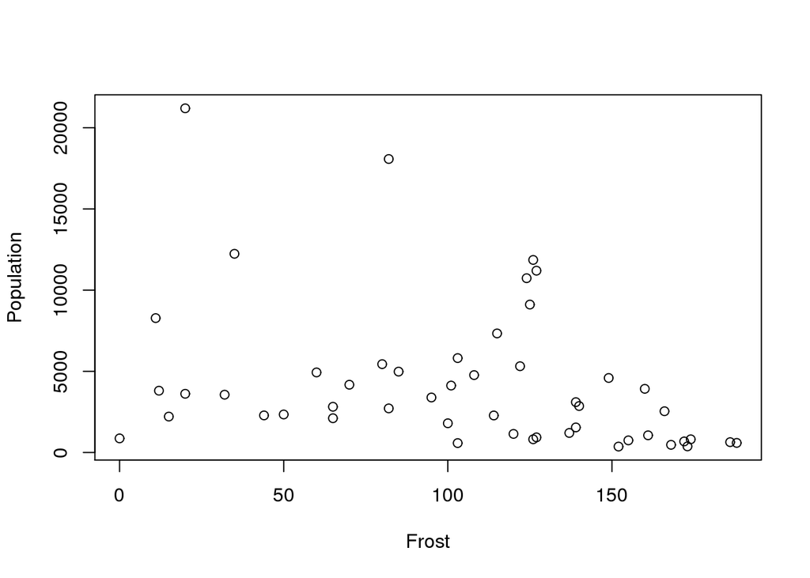

```r
plot(Population ~ Frost, data = x77)  #Plot the Pop data against Frost
```

```r
cor(x77$Population, x77$Frost)  #There is an R of -.33 so there is no useful correlation
```

```
## [1] -0.3321525
```

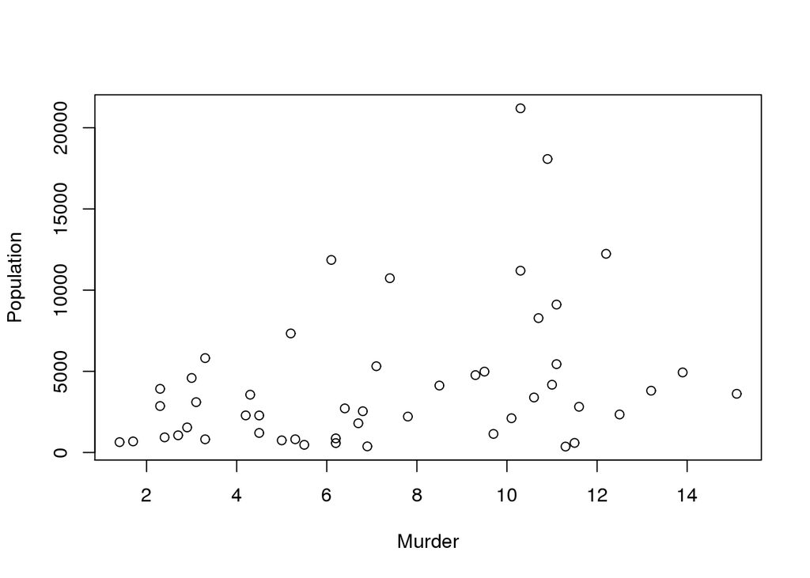

```r
plot(Population ~ Murder, data = x77)  #Plots the population against murder
```

```r
cor(x77$Population, x77$Murder)  # There is a correlation of .34 so no useful correlation
```

```
## [1] 0.3436428
```

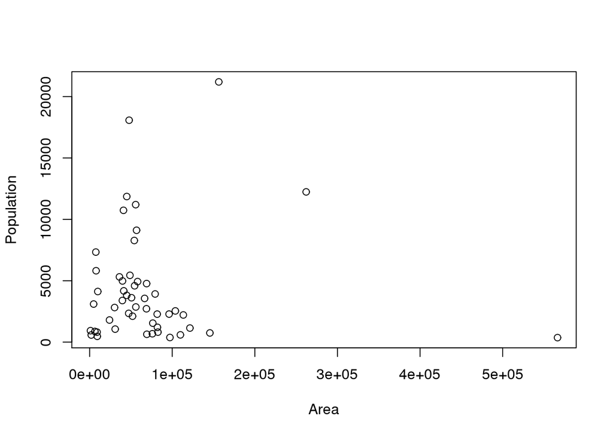

```r
plot(Population ~ Area, data = x77)  # Plots the population against area
```

```r
cor(x77$Population, x77$Area)  # R of .02 so definitely no correlation
```

```
## [1] 0.02254384
```

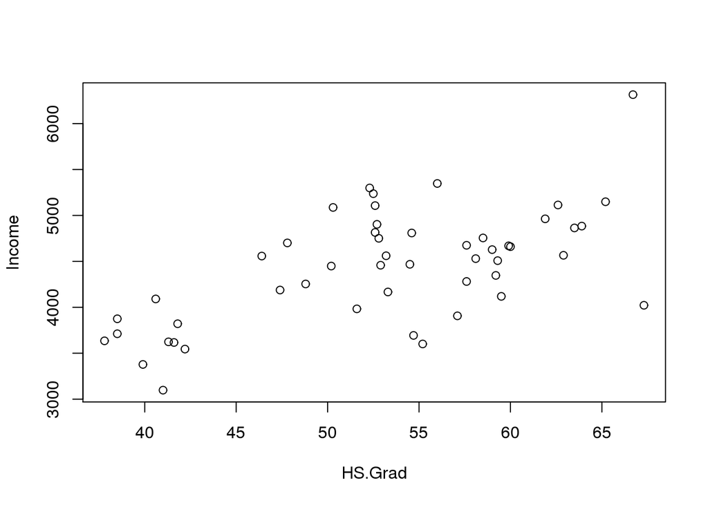

```r
plot(Income ~ HS.Grad, data = x77)  # Plots income against HS Grads
```

```r
cor(x77$Income, x77$HS.Grad)  # R of .62 so there is a slight linear correlation.
```

```
## [1] 0.6199323
```